# Dissertation Participant 2

## Demographic Information

Participant Demographics

| Sex | Age | Prior Concussions | History of Depression or Anxiety |
| --- | --- | --- | --- |
| Female | 15 | 1 | Yes |

## Outcome Measurements

### GAS Hierarchy - Number of minutes per week spent studying for Spanish class

| Level | Outcome |
| --- | --- |
| Much more than expected | 36 to 45 minutes |
| More than expected | 26 to 35 minutes |
| Expected | 16 to 25 minutes |
| Baseline | 6 to 15 minutes |
| Decline | 0 to 5 minutes |

### BRIEF-2

Self-report responses that guided treatment at time of pre-baseline data collection:

- Task Completion Scale
- Plan/Organize Scale
- Cognitive Regulation Index

The only elevated scores from the parent-report pre-baseline were the Shift Scale, Emotional Control Scale, and Emotional Regulation Index

#### BRIEF-2 Self-Report

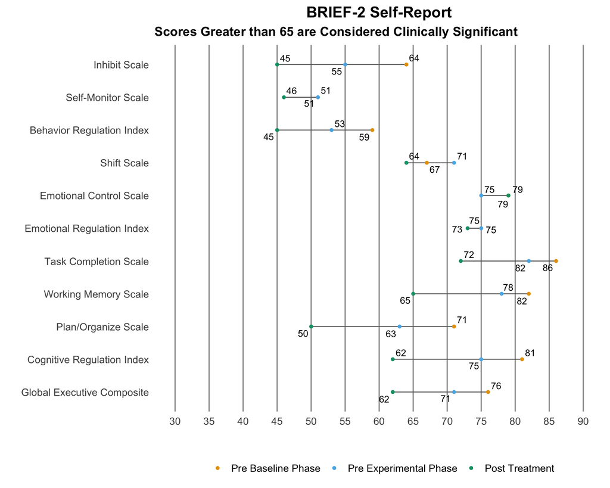

#### BRIEF-2 Self-Report Table Version 1

| Scale/Index | Pre Baseline Phase | Pre Experimental Phase | Post Treatment |
| --- | --- | --- | --- |
| Inhibit Scale | 64 | 55 | 45 |
| Self-Monitor Scale | 51 | 51 | 46 |
| Behavior Regulation Index | 59 | 53 | 45 |
| Shift Scale | 67 | 71 | 64 |
| Emotional Control Scale | 79 | 75 | 79 |
| Emotional Regulation Index | 75 | 75 | 73 |
| Task Completion Scale | 86 | 82 | 72 |
| Working Memory Scale | 82 | 78 | 65 |
| Plan/Organize Scale | 71 | 63 | 50 |
| Cognitive Regulation Index | 81 | 75 | 62 |

[output cut: 1 more lines]

#### BRIEF-2 Self-Report Table Version 2

| Scale/Index | Pre Baseline Phase | Pre Experimental Phase | Post Treatment |
| --- | --- | --- | --- |
| Inhibit Scale | 64 | 55 | 45 |
| Self-Monitor Scale | 51 | 51 | 46 |
| Behavior Regulation Index | 59 | 53 | 45 |
| Shift Scale | 67 | 71 | 64 |
| Emotional Control Scale | 79 | 75 | 79 |
| Emotional Regulation Index | 75 | 75 | 73 |
| Task Completion Scale | 86 | 82 | 72 |
| Working Memory Scale | 82 | 78 | 65 |
| Plan/Organize Scale | 71 | 63 | 50 |
| Cognitive Regulation Index | 81 | 75 | 62 |

[output cut: 1 more lines]

#### BRIEF-2 Parent-Report

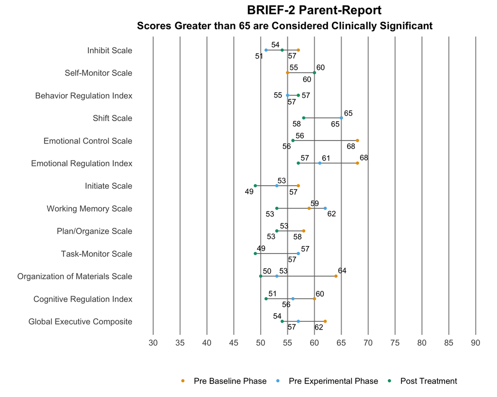

#### BRIEF-2 Parent-Report Table Version 1

| Scale/Index | Pre Baseline Phase | Pre Experimental Phase | Post Treatment |
| --- | --- | --- | --- |
| Inhibit Scale | 57 | 51 | 54 |
| Self-Monitor Scale | 55 | 60 | 60 |
| Behavior Regulation Index | 57 | 55 | 57 |
| Shift Scale | 65 | 65 | 58 |
| Emotional Control Scale | 68 | 56 | 56 |
| Emotional Regulation Index | 68 | 61 | 57 |
| Initiate Scale | 57 | 53 | 49 |
| Working Memory Scale | 59 | 62 | 53 |
| Plan/Organize Scale | 58 | 53 | 53 |
| Task-Monitor Scale | 57 | 57 | 49 |

[output cut: 3 more lines]

#### BRIEF-2 Parent-Report Table Version 2

| Scale/Index | Pre Baseline Phase | Pre Experimental Phase | Post Treatment |
| --- | --- | --- | --- |
| Inhibit Scale | 57 | 51 | 54 |
| Self-Monitor Scale | 55 | 60 | 60 |
| Behavior Regulation Index | 57 | 55 | 57 |
| Shift Scale | 65 | 65 | 58 |
| Emotional Control Scale | 68 | 56 | 56 |
| Emotional Regulation Index | 68 | 61 | 57 |
| Initiate Scale | 57 | 53 | 49 |
| Working Memory Scale | 59 | 62 | 53 |
| Plan/Organize Scale | 58 | 53 | 53 |
| Task-Monitor Scale | 57 | 57 | 49 |

[output cut: 3 more lines]

### CLASS

Self-report responses that guided treatment at time of pre-baseline data collection:

- Difficulty taking notes
- Difficulty understanding new material
- Difficulty studying for tests or quizzes

Parent-report responses that guided treatment at time of pre-baseline data collection:

- Difficulty taking notes
- Trouble remembering what was studied

#### CLASS Self 1

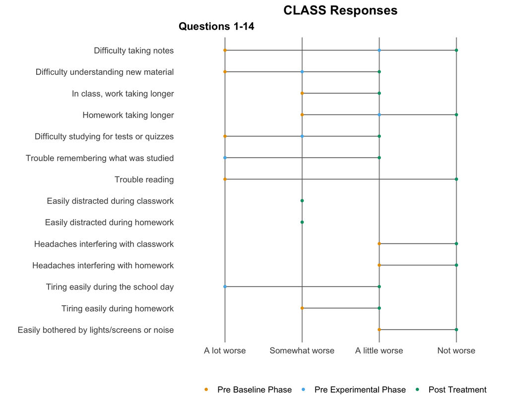

#### CLASS Self 2

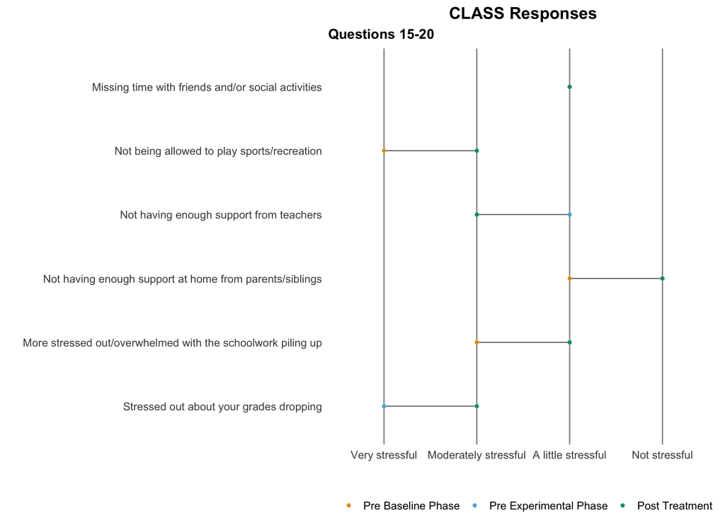

#### ClASS Self Table

| Question | Pre Baseline Phase | Pre Experimental Phase | Post Treatment |
| --- | --- | --- | --- |
| Difficulty taking notes | A lot worse | A little worse | Not worse |
| Difficulty understanding new material | A lot worse | Somewhat worse | A little worse |
| In class, work taking longer | Somewhat worse | A little worse | A little worse |
| Homework taking longer | Somewhat worse | A little worse | Not worse |
| Difficulty studying for tests or quizzes | A lot worse | Somewhat worse | A little worse |
| Trouble remembering what was studied | A lot worse | A lot worse | A little worse |
| Trouble reading | A lot worse | Not worse | Not worse |
| Easily distracted during classwork | Somewhat worse | Somewhat worse | Somewhat worse |
| Easily distracted during homework | Somewhat worse | Somewhat worse | Somewhat worse |
| Headaches interfering with classwork | A little worse | Not worse | Not worse |

[output cut: 10 more lines]

#### CLASS Parent 1

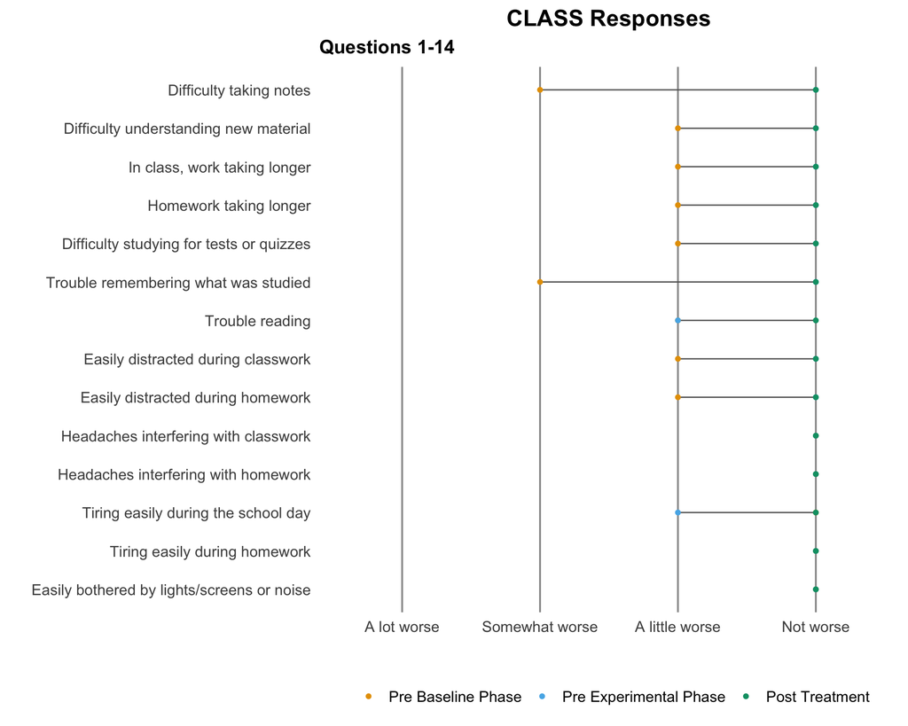

#### CLASS parent 2

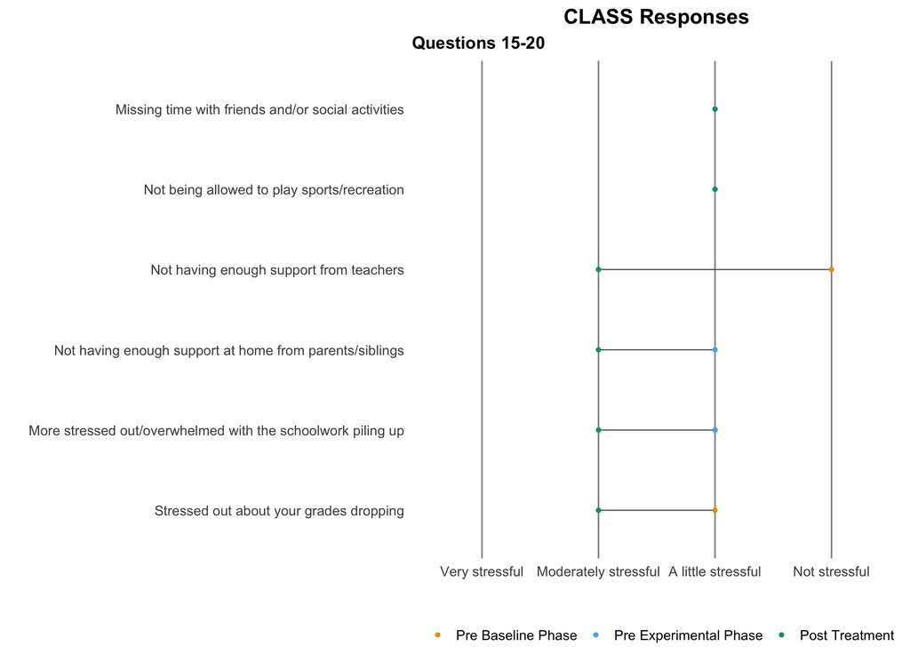

#### ClASS Parent Table

| Question | Pre Baseline Phase | Pre Experimental Phase | Post Treatment |
| --- | --- | --- | --- |
| Difficulty taking notes | Somewhat worse | Not worse | Not worse |
| Difficulty understanding new material | A little worse | Not worse | Not worse |
| In class, work taking longer | A little worse | Not worse | Not worse |
| Homework taking longer | A little worse | Not worse | Not worse |
| Difficulty studying for tests or quizzes | A little worse | Not worse | Not worse |
| Trouble remembering what was studied | Somewhat worse | Not worse | Not worse |
| Trouble reading | A little worse | A little worse | Not worse |
| Easily distracted during classwork | A little worse | Not worse | Not worse |
| Easily distracted during homework | A little worse | Not worse | Not worse |
| Headaches interfering with classwork | Not worse | Not worse | Not worse |

[output cut: 10 more lines]

### PCSS

Pre-baseline symptom severity levels that guided treatment selection:

- Difficulty concentrating
- Difficulty remembering
- Cognitive symptom cluster

#### All Scores

| Symptom | Pre Baseline Phase | Pre Experimental Phase | Post Treatment |
| --- | --- | --- | --- |
| Headache | 0 | 0 | 0 |
| Nausea | 0 | 3 | 0 |
| Vomiting | 0 | 0 | 0 |
| Balance problems | 1 | 1 | 1 |
| Dizziness | 0 | 0 | 1 |
| Fatigue | 0 | 2 | 1 |
| Trouble falling asleep | 2 | 0 | 0 |
| Excessive sleep | 2 | 2 | 0 |
| Loss of sleep | 2 | 0 | 0 |
| Drowsiness | 0 | 3 | 0 |

[output cut: 19 more lines]

#### Symptom Scores

| Symptom | Pre Baseline Phase | Pre Experimental Phase | Post Treatment |
| --- | --- | --- | --- |
| Headache | 0 | 0 | 0 |
| Nausea | 0 | 3 | 0 |
| Vomiting | 0 | 0 | 0 |
| Balance problems | 1 | 1 | 1 |
| Dizziness | 0 | 0 | 1 |
| Fatigue | 0 | 2 | 1 |
| Trouble falling asleep | 2 | 0 | 0 |
| Excessive sleep | 2 | 2 | 0 |
| Loss of sleep | 2 | 0 | 0 |
| Drowsiness | 0 | 3 | 0 |

[output cut: 12 more lines]

#### Total and Cluster Scores

| Symptom | Pre Baseline Phase | Pre Experimental Phase | Post Treatment |
| --- | --- | --- | --- |
| Total Score | 27 | 41 | 15 |
| Headache-Migraine Cluster | 0 | 0 | 0 |
| Cognitive Cluster | 9 | 12 | 5 |
| Anxiety-Mood Cluster | 9 | 17 | 5 |
| Ocular-Motor Cluster | 2 | 1 | 2 |
| Vestibular Cluster | 1 | 4 | 2 |
| Sleep Cluster | 6 | 7 | 1 |

## Repeated Measurements

### Status Tracking Measurement

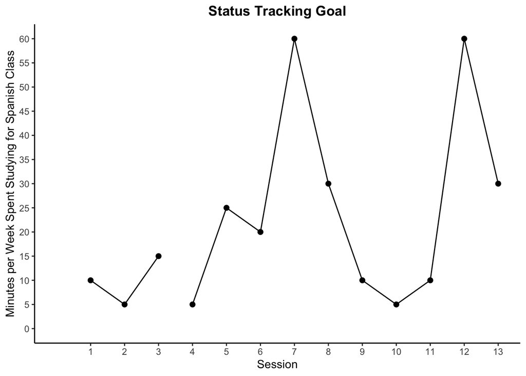

### Repeated Strategy Measurements

Cognitive Strategy: Use of the reminders app to set specific times throughout the week to dedicate to studying for Spanish class.

- Participant will adhere to the two set reminders per week.

Cognitive Strategy identified during session 11 to be measured sessions 12 and 13: have an accountability partner to study with for a desired amount of time.

#### Frequency of Use of Reminders App Strategy

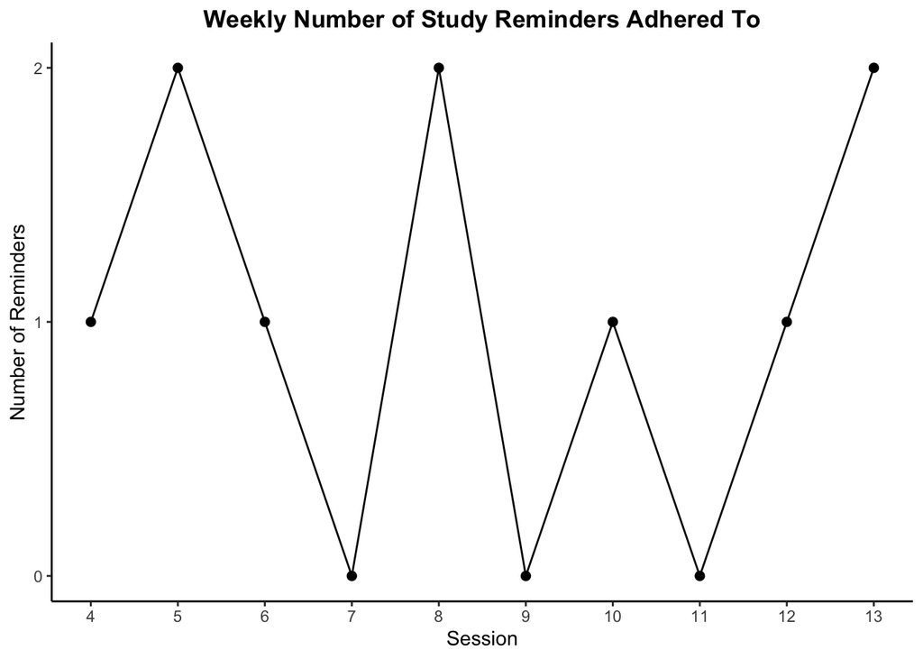

#### Perceived Helpfulness of Reminders App Strategy

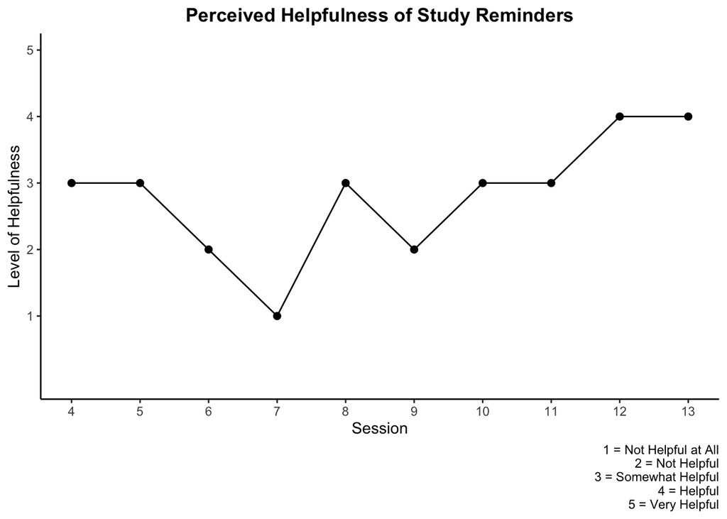

#### Frequency of Use of Accountability Partner Strategy

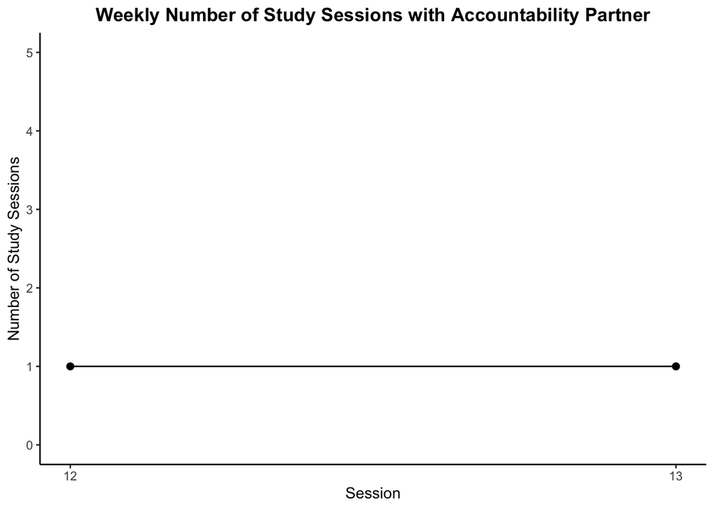

#### Perceived Helpfulness of Accountability Partner Strategy

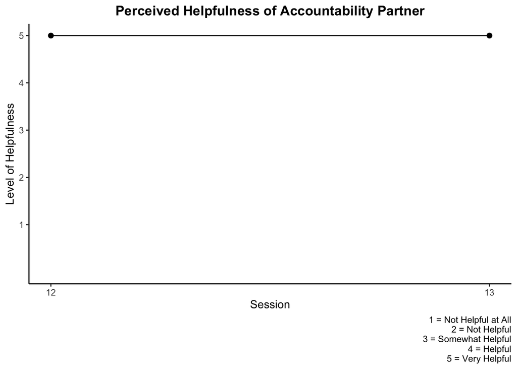

## Treatment Implementation Measurements

### TARF

The TARF is used to measure social validity.

| Question | Response |
| --- | --- |
| The clinician's teaching of the cognitive strategy was effective | Agree |
| I was motivated to use my strategy outside of therapy sessions | Agree |
| The duration of time to learn my cognitive strategy was longer than anticipated | Neutral |
| I am confident I learned my cognitive strategy | Strongly agree |
| Learning a cognitive strategy helped me reach my school and other goals | Agree |
| I liked attending therapy sessions | Agree |
| I experienced discomfort learning and implementing a cognitive strategy to address my school and other goals | Neutral |
| To what extent do you feel like you understand the concept and importance of cognitive strategy instruction? | I greatly understand the importance of cognitive strategy instruction |
| Anything else you would like to share with us? | Not that I can think of |

### Treatment Compliance

Participant 2 did not cancel or reschedule any sessions.